# Stop and Search in London Visualization

Tianchi Wu

2021-01-02

# 1 Context

According to the Metropolitan Police(the Met), the main reason they use stop and search in London is to “allow officers to investigate their suspicions about an individual without having to arrest them.” [source](https://www.met.police.uk/advice/advice-and-information/st-s/stop-and-search/how-we-use-stop-and-search/)

Our concern is: * Does the Met conduct effective stop and searches, i.e. detecting real criminal suspects from these actions? * Does the Met conduct fair stop and searches regarding objects’ gender? * What is the geographical distribution of stop and search? Does the Met have a target locaiton?

We’ll do some interesting data visualization to find out, using Metropolitan Police stop and search data in Sep 2020.[source](https://data.police.uk/data/)

# 2 Efficiency of stop and searches

```r
#import the data
stop_and_search <- read.csv("stop-and-search.csv", header = TRUE)

#firstly look at the data
skim(stop_and_search)
```

Data summary

| Name | stop_and_search |
| --- | --- |
| Number of rows | 19928 |
| Number of columns | 15 |
| _______________________ |  |
| Column type frequency: |  |
| character | 10 |
| logical | 3 |
| numeric | 2 |
| ________________________ |  |
| Group variables | None |

**Variable type: character**

| skim_variable | n_missing | complete_rate | min | max | empty | n_unique | whitespace |
| --- | --- | --- | --- | --- | --- | --- | --- |
| Type | 0 | 1 | 13 | 25 | 0 | 3 | 0 |
| Date | 0 | 1 | 25 | 25 | 0 | 10081 | 0 |
| Part.of.a.policing.operation | 0 | 1 | 5 | 5 | 0 | 1 | 0 |
| Gender | 0 | 1 | 0 | 6 | 248 | 4 | 0 |
| Age.range | 0 | 1 | 0 | 8 | 2620 | 6 | 0 |
| Self.defined.ethnicity | 0 | 1 | 0 | 84 | 243 | 18 | 0 |
| Officer.defined.ethnicity | 0 | 1 | 0 | 5 | 426 | 5 | 0 |
| Legislation | 0 | 1 | 30 | 55 | 0 | 4 | 0 |
| Object.of.search | 0 | 1 | 0 | 35 | 38 | 9 | 0 |
| Outcome | 0 | 1 | 6 | 31 | 0 | 6 | 0 |

**Variable type: logical**

| skim_variable | n_missing | complete_rate | mean | count |
| --- | --- | --- | --- | --- |
| Policing.operation | 19928 | 0 | NaN | : |
| Outcome.linked.to.object.of.search | 19928 | 0 | NaN | : |
| Removal.of.more.than.just.outer.clothing | 19928 | 0 | NaN | : |

**Variable type: numeric**

| skim_variable | n_missing | complete_rate | mean | sd | p0 | p25 | p50 | p75 | p100 | hist |
| --- | --- | --- | --- | --- | --- | --- | --- | --- | --- | --- |
| Latitude | 2309 | 0.88 | 51.51 | 0.06 | 51.29 | 51.48 | 51.5 | 51.55 | 52.61 | ▇▂▁▁▁ |
| Longitude | 2309 | 0.88 | -0.11 | 0.14 | -0.49 | -0.19 | -0.1 | -0.02 | 1.73 | ▇▃▁▁▁ |

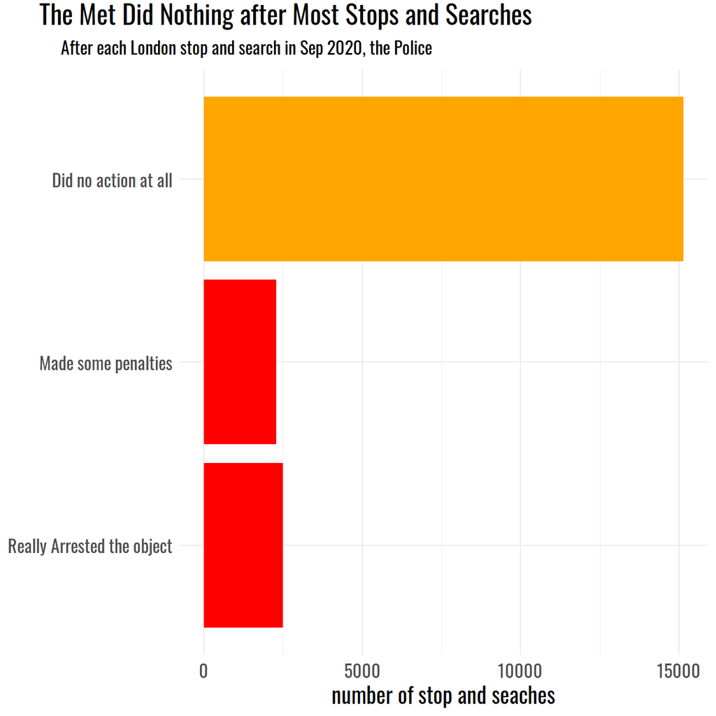

```r
#define color to use
my_colours <- c("red", "red", "orange")

#use column Outcome to define the effectiveness of a single stop and search. If we arrest the object, it would be defined as a very effective s&s. If we have no further action, it would be defined as ineffective.
stop_and_search <- stop_and_search %>%
  mutate(
    outcome_effectiveness = case_when(
      Outcome == "Arrest" ~ "Really Arrested the object",
      Outcome == "A no further action disposal" ~ "Did no action at all",
      TRUE ~ "Made some penalties")) %>%
  mutate(outcome_effectiveness = factor(outcome_effectiveness,
                                         levels = c("Really Arrested the object","Made some penalties","Did no action at all"), ordered=TRUE))

#make barplots and use orange versus red to emphasize the contrast
p1<- ggplot(stop_and_search, aes(y = outcome_effectiveness, fill = outcome_effectiveness)) +
  geom_bar() +
  scale_fill_manual(values = my_colours)+
  theme_minimal() +
  theme(
    axis.title.y = element_blank(),
    legend.position = "none",
    text = element_text(size=15, family = "Oswald"),
    plot.title = element_text(hjust = -4, vjust=2.12),
    plot.subtitle = element_text(hjust = -0.8, vjust=2.12,size = 12)
    ) +
 labs(
  title = "The Met Did Nothing after Most Stops and Searches",
  subtitle = "After each London stop and search in Sep 2020, the Police  ",
  x = "number of stop and seaches")

p1
```

# 3 Equality of stop and searches.

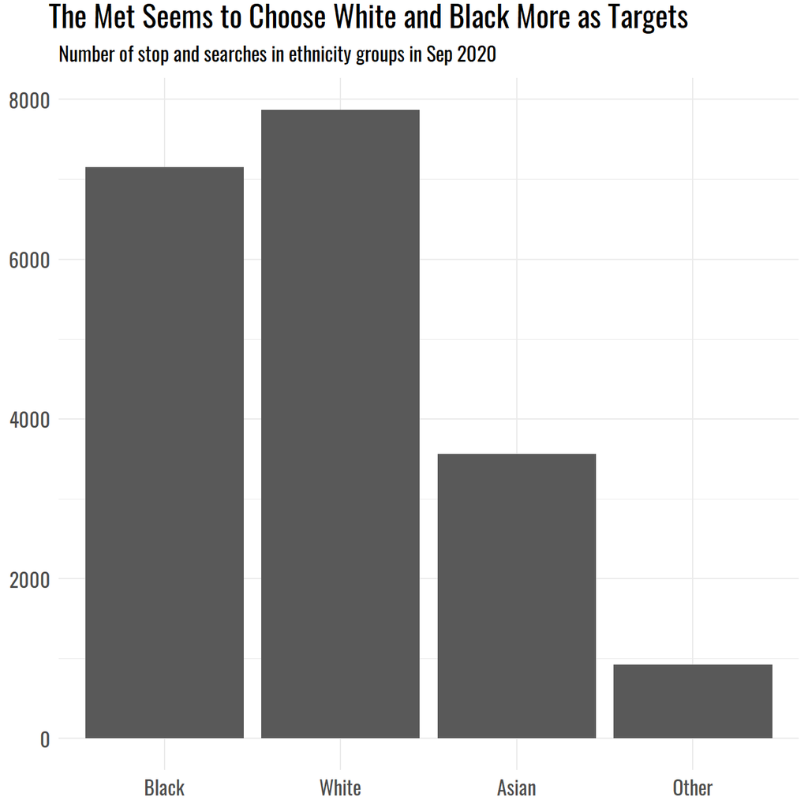

```r
#I decide to use officer defined ethnicity since it is more general and succinct.
#There are some meaningless spaces in ehnicity so I only choose clear four groups we want to analyse.
stop_and_search_cleaned <- stop_and_search %>%
  filter(Officer.defined.ethnicity == "White"|
         Officer.defined.ethnicity == "Black"|
         Officer.defined.ethnicity =="Asian"|
         Officer.defined.ethnicity =="Other") %>%
  mutate(Officer.defined.ethnicity = factor(Officer.defined.ethnicity,
        levels = c("Black", "White", "Asian", "Other"), ordered = TRUE))

#we first use barplots to look at distribution of ethnicity
p2<- ggplot(stop_and_search_cleaned, aes(x = Officer.defined.ethnicity)) +
  geom_bar() +
  scale_fill_manual(values = my_colours)+
  theme_minimal() +
  theme(
    axis.title.x = element_blank(),
    axis.title.y = element_blank(),
    legend.position = "none",
    text = element_text(size=15, family = "Oswald"),
    plot.title = element_text(hjust = -0.1, vjust=2.12),
    plot.subtitle = element_text(hjust = -0, vjust=2.12,size = 12)
    ) +
 labs(
  title = "The Met Seems to Choose White and Black More as Targets",
  subtitle = "Number of stop and searches in ethnicity groups in Sep 2020")

p2
```

It seems that the Met tends to choose White and Black more as their stop and search targets, but is that really the case? Because different ethnicity groups have different population in London, so I want to normalize them by dividing a population efficient.

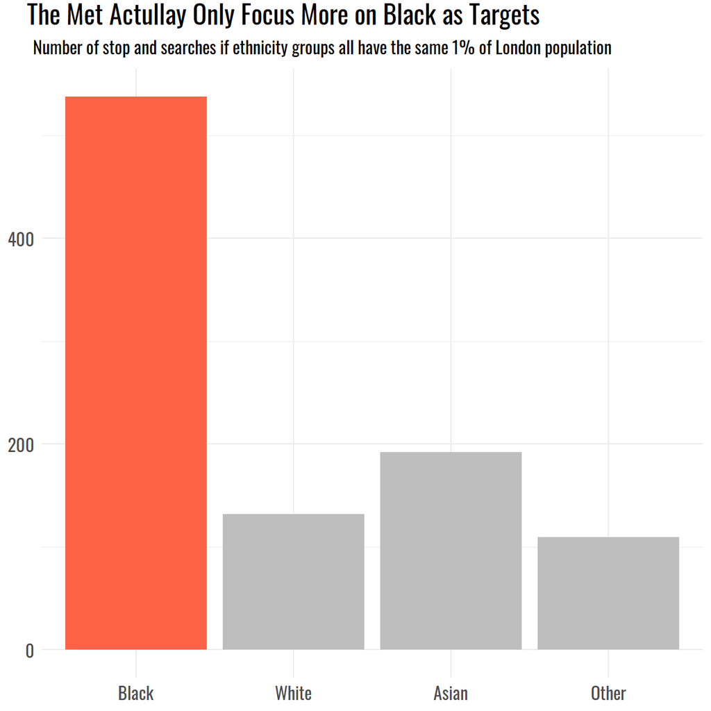

```r
#from https://worldpopulationreview.com/world-cities/london-population I get the ethnicity percentage in London: White = 59.8%, Asian = 18.5%, Black = 13.3%, Other = 8.4%

#count for each ethnicity group's number and add a new varibale of a population efficient.
stop_and_search_ethnicity <- stop_and_search_cleaned %>%
  count(Officer.defined.ethnicity) %>%
  mutate(pop_coef = 0)
stop_and_search_ethnicity$pop_coef = case_when(
stop_and_search_ethnicity$Officer.defined.ethnicity == "White" ~ 59.8,
stop_and_search_ethnicity$Officer.defined.ethnicity == "Asian" ~ 18.5,
stop_and_search_ethnicity$Officer.defined.ethnicity == "Black" ~ 13.3,
    TRUE ~ 8.4 )

ss_eth_normalized <- stop_and_search_ethnicity %>%
  mutate(normalized_count = n/pop_coef) %>%
  arrange(desc(normalized_count))

# Then we use the data normalized by population coefficient to figure out the real case.

my_colours_2 <- c("tomato", "grey", "grey", "grey")
p3 <- ggplot(ss_eth_normalized, aes(x = Officer.defined.ethnicity, y = normalized_count, fill = Officer.defined.ethnicity)) +
  geom_col() +
  scale_fill_manual(values = my_colours_2)+
  theme_minimal() +
  theme(
    axis.title.x = element_blank(),
    axis.title.y = element_blank(),
    legend.position = "none",
    text = element_text(size=15, family = "Oswald"),
    plot.title = element_text(hjust = -0.1, vjust=2.12),
    plot.subtitle = element_text(hjust = -0.11, vjust=2.12,size = 12)
    ) +
 labs(
  title = "The Met Actullay Only Focus More on Black as Targets",
  subtitle = "Number of stop and searches if ethnicity groups all have the same 1% of London population")

p3
```

# 4 Geographical location of stops and searches.

```r
#drop the NAs in Latitude and Longitude

stop_and_search_location <- stop_and_search %>%
  drop_na(Latitude, Longitude) %>%
  filter(Outcome == "Arrest")


#since we have the longitude and latitude of all stop and search, I decide to use the leaflet to plot the geo locations of all stop and searches.
leaflet(data = stop_and_search_location) %>%
  addProviderTiles("OpenStreetMap.Mapnik") %>%
  addCircleMarkers(lng = ~Longitude,
                   lat = ~Latitude,
                   radius = 1,
                   fillColor = "red",
                   fillOpacity = 0.2,
                   popup = ~Age.range,
                   label = ~Officer.defined.ethnicity)
```

[interactive chart not shown]

# 5 Part 2

We’ll use data of London stop and search ranging from Oct 2017 to Sep 2020 and make some geographical visualizations.

And since we’re already very familiar with the term, I’ll use “S&S” to replace “Stop and Search” for easy use.

# 6 Read Files and Data Wrangling

```r
# read many CSV files
data_dir <- "data/stop-search"

files <- fs::dir_ls(path = data_dir, regexp = "\\.csv$", recurse = TRUE)

#read them all in using vroom::vroom()
stop_search_data <- vroom(files, id = "source")

#read them all in using vroom::vroom()
stop_search_data <- vroom(files, id = "source")

# Use janitor to clean names, and add more variables
stop_search_all <- stop_search_data %>%
  janitor::clean_names() %>%
  mutate(month = month(date),
         month_name = month(date, label=TRUE, abbr = TRUE),
         year= year(date),
         month_year = paste0(year, "-",month)
  ) %>%

# rename longitude/latitude to lng/lat
rename(lng = longitude,
       lat = latitude)

# skimr::skim() to inspect and get a feel for the data
skim(stop_search_all)
```

Data summary

| Name | stop_search_all |
| --- | --- |
| Number of rows | 692231 |
| Number of columns | 20 |
| _______________________ |  |
| Column type frequency: |  |
| character | 10 |
| factor | 1 |
| logical | 4 |
| numeric | 4 |
| POSIXct | 1 |
| ________________________ |  |
| Group variables | None |

**Variable type: character**

| skim_variable | n_missing | complete_rate | min | max | empty | n_unique | whitespace |
| --- | --- | --- | --- | --- | --- | --- | --- |
| source | 0 | 1.00 | 65 | 65 | 0 | 36 | 0 |
| type | 0 | 1.00 | 13 | 25 | 0 | 3 | 0 |
| gender | 9160 | 0.99 | 4 | 6 | 0 | 3 | 0 |
| age_range | 90885 | 0.87 | 5 | 8 | 0 | 5 | 0 |
| self_defined_ethnicity | 8971 | 0.99 | 13 | 84 | 0 | 17 | 0 |
| officer_defined_ethnicity | 13594 | 0.98 | 5 | 5 | 0 | 4 | 0 |
| legislation | 0 | 1.00 | 30 | 55 | 0 | 4 | 0 |
| object_of_search | 1800 | 1.00 | 8 | 35 | 0 | 8 | 0 |
| outcome | 0 | 1.00 | 6 | 39 | 0 | 14 | 0 |
| month_year | 0 | 1.00 | 6 | 7 | 0 | 37 | 0 |

**Variable type: factor**

| skim_variable | n_missing | complete_rate | ordered | n_unique | top_counts |
| --- | --- | --- | --- | --- | --- |
| month_name | 0 | 1 | TRUE | 12 | May: 77301, Apr: 64254, Jun: 63850, Aug: 61721 |

**Variable type: logical**

| skim_variable | n_missing | complete_rate | mean | count |
| --- | --- | --- | --- | --- |
| part_of_a_policing_operation | 0 | 1 | 0 | FAL: 692231 |
| policing_operation | 692231 | 0 | NaN | : |
| outcome_linked_to_object_of_search | 692231 | 0 | NaN | : |
| removal_of_more_than_just_outer_clothing | 692231 | 0 | NaN | : |

**Variable type: numeric**

| skim_variable | n_missing | complete_rate | mean | sd | p0 | p25 | p50 | p75 | p100 | hist |
| --- | --- | --- | --- | --- | --- | --- | --- | --- | --- | --- |
| lat | 87290 | 0.87 | 51.51 | 0.06 | 51.26 | 51.47 | 51.5 | 51.55 | 53.30 | ▇▁▁▁▁ |
| lng | 87290 | 0.87 | -0.11 | 0.14 | -2.93 | -0.19 | -0.1 | -0.03 | 1.73 | ▁▁▅▇▁ |
| month | 0 | 1.00 | 6.20 | 3.29 | 1.00 | 4.00 | 6.0 | 9.00 | 12.00 | ▇▆▆▆▆ |
| year | 0 | 1.00 | 2019.05 | 0.86 | 2017.00 | 2018.00 | 2019.0 | 2020.00 | 2020.00 | ▁▅▁▇▇ |

**Variable type: POSIXct**

| skim_variable | n_missing | complete_rate | min | max | median | n_unique |
| --- | --- | --- | --- | --- | --- | --- |
| date | 0 | 1 | 2017-09-30 23:10:00 | 2020-09-30 22:55:00 | 2019-08-16 15:20:00 | 334484 |

```r
# concentrate in top  searches, age_ranges, and officer defined ethnicities
which_searches <- c("Controlled drugs", "Offensive weapons","Stolen goods" )
which_ages <- c("10-17", "18-24","25-34", "over 34")
which_ethnicity <- c("White", "Black", "Asian")

stop_search_offence <- stop_search_all %>%

  # filter out those stop-and-search where no further action was taken
  filter(outcome != "A no further action disposal") %>%

  #filter out those rows with no latitude/longitude
  drop_na(lng,lat) %>%

  # concentrate in top searches, age_ranges, and officer defined ethnicities
  filter(object_of_search %in% which_searches) %>%
  filter(age_range %in% which_ages) %>%
  filter(officer_defined_ethnicity %in% which_ethnicity) %>%

  # relevel factors so everything appears in correct order
  mutate(
    object_of_search = fct_relevel(object_of_search,
                                   c("Controlled drugs", "Offensive weapons","Stolen goods")),
    age_range = fct_relevel(age_range,
                            c("10-17", "18-24", "25-34", "over 34")),
    officer_defined_ethnicity = fct_relevel(officer_defined_ethnicity,
                                            c("White", "Black", "Asian"))
  )

# according to later visualization making, we notice a highly abnormal geo location in one observation. We decided to remove it:

stop_search_offence <- stop_search_offence %>%
  filter(lat < 52 & lng >-0.6)

# make it a shape file using WGS84 lng/lat coordinates
stop_search_offence_sf <-  st_as_sf(stop_search_offence,
                              coords=c('lng', 'lat'),
                              crs = 4326)

st_geometry(stop_search_offence_sf) # what is the geometry ?
```

```
## Geometry set for 133782 features
## geometry type:  POINT
## dimension:      XY
## bbox:           xmin: -0.508 ymin: 51.3 xmax: 0.302 ymax: 51.7
## geographic CRS: WGS 84
## First 5 geometries:
```

```r
# stop_search_offence_sf = geographic CRS: WGS 84

# make sure you have the same direcory stucture to get London wards shapefile
london_wards_sf <- read_sf(here::here("data/London-wards-2018_ESRI","London_Ward.shp"))

st_geometry(london_wards_sf)
```

```
## Geometry set for 657 features
## geometry type:  POLYGON
## dimension:      XY
## bbox:           xmin: 504000 ymin: 156000 xmax: 562000 ymax: 201000
## projected CRS:  OSGB 1936 / British National Grid
## First 5 geometries:
```

```r
# london_wards_sf = projected CRS:  OSGB 1936 / British National Grid

# change the CRS to use WGS84 lng/lat pairs
london_wgs84 <-  london_wards_sf %>%
  st_transform(4326) # transform CRS to WGS84, latitude/longitude

st_geometry(london_wgs84)
```

```
## Geometry set for 657 features
## geometry type:  POLYGON
## dimension:      XY
## bbox:           xmin: -0.51 ymin: 51.3 xmax: 0.334 ymax: 51.7
## geographic CRS: WGS 84
## First 5 geometries:
```

# 7 Demographic Distribution

Since we have a much larger dataset, now I want to look at the age and gender distribution of objects of stops and searches.

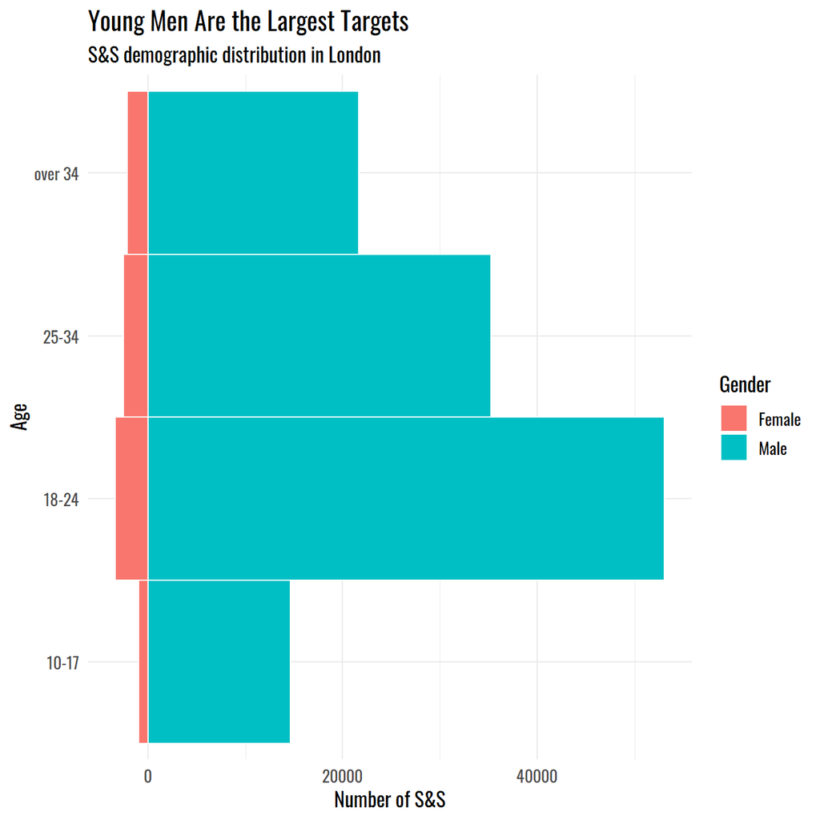

```r
# pyramid histograms
ss_demo <- stop_search_offence %>%
  drop_na(gender, age_range) %>%
  filter(gender != "Other") %>%
  group_by(gender, age_range) %>%
  summarize(total = n())

p1 <- ggplot(ss_demo,
       aes(y = age_range,
           x = ifelse(gender == "Male",
                      total, -total),
           fill = gender)) +
  geom_col(width = 1, color = "white")+
  xlab("Number of S&S")+
  ylab("Age")+
  labs(
  title = "Young Men Are the Largest Targets",
  subtitle = "S&S demographic distribution in London",
  fill = "Gender")+
  theme_minimal()+
  theme(text = element_text(size=12, family = "Oswald"),
        plot.title = element_text(size = 15),
        plot.subtitle = element_text(size = 12))

p1
```

# 8 Geographic Distribution

In this work, we’ll focus more on the geographical distribution of stops and searches in London.

## 8.1 Objects of search

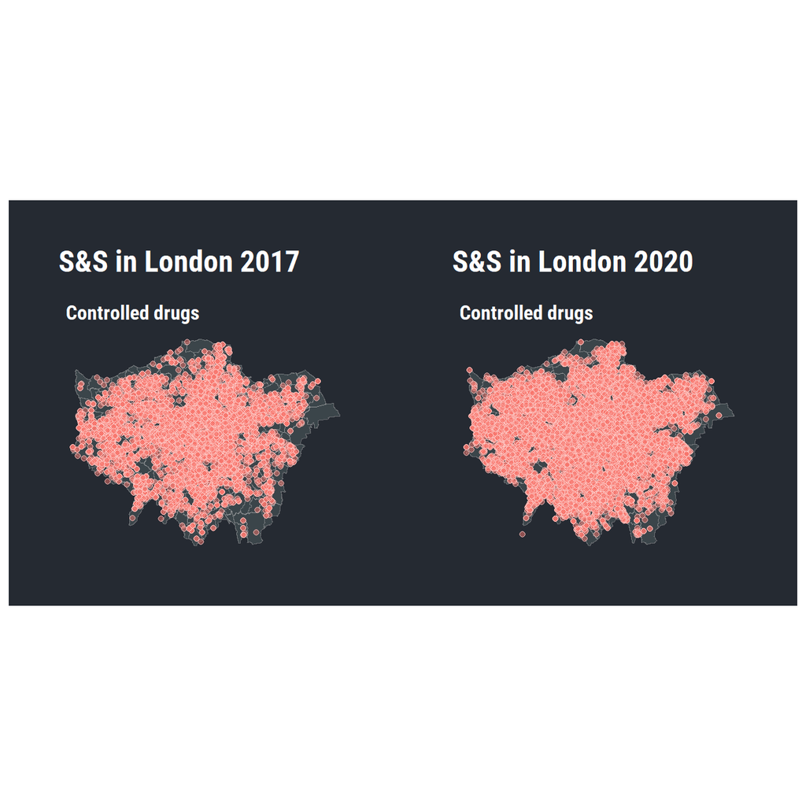

```r
# we could first look at distribution of different search objects at London for each year since dataset is too large

# we choose the start year(2017) and the most recent year(2020)
# year 2017
ss_2017 <- stop_search_offence_sf %>%
  filter(year == "2017")

p2 <- ggplot() +
  # draw polygons from London wards shapefile
  geom_sf(data = london_wgs84, fill = "#3B454A", size = 0.125, colour = "#b2b2b277") +
  # add points from stop-and-search shapefile
  geom_sf(
    data = ss_2017, aes(fill = object_of_search),
    color = "white", size = 1.5, alpha = 0.5, shape = 21,
    show.legend = FALSE
  ) +
  theme_minimal()+
  coord_sf(datum = NA) + #remove coordinates
  facet_wrap(~object_of_search) +
  labs(title = "S&S in London 2017") +
  hrbrthemes::theme_ft_rc(grid="", strip_text_face = "bold") +
  theme(axis.text = element_blank()) +
  theme(strip.text = element_text(color = "white"))+
  NULL

# year 2020
ss_2020_drugs <- stop_search_offence_sf %>%
  filter(year == "2020") %>%
  filter(object_of_search == "Controlled drugs")

p3 <- ggplot() +
  # draw polygons from London wards shapefile
  geom_sf(data = london_wgs84, fill = "#3B454A", size = 0.125, colour = "#b2b2b277") +
  # add points from stop-and-search shapefile
  geom_sf(
    data = ss_2020_drugs, aes(fill = object_of_search),
    color = "white", size = 1.5, alpha = 0.5, shape = 21,
    show.legend = FALSE
  ) +
  theme_minimal()+
  coord_sf(datum = NA) + #remove coordinates
  facet_wrap(~object_of_search) +
  labs(title = "S&S in London 2020") +
  hrbrthemes::theme_ft_rc(grid="", strip_text_face = "bold") +
  theme(axis.text = element_blank()) +
  theme(strip.text = element_text(color = "white"))+
  NULL

# We found that the only object of search conducted by the Met in 2017 is "Controlled drugs". Let's see how much the s&s of controlled drugs evolve into in 2020.
p2 + p3
```

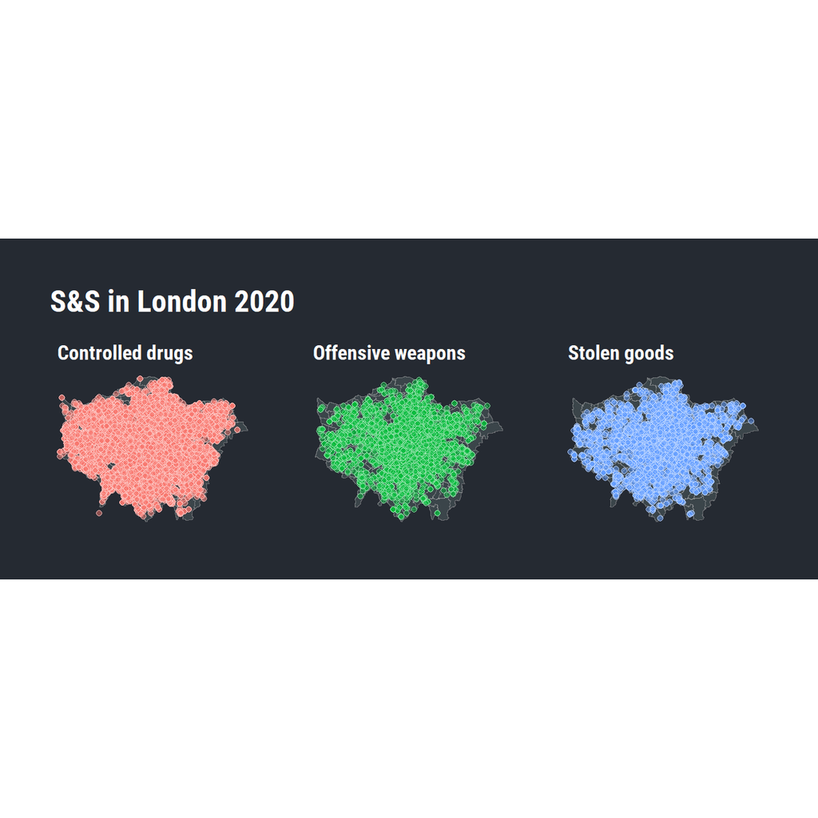

```r
# How about other objects? Let's have a view of all objects of search in 2020.

ss_2020 <- stop_search_offence_sf %>%
  filter(year == "2020")

p4 <- ggplot() +
  # draw polygons from London wards shapefile
  geom_sf(data = london_wgs84, fill = "#3B454A", size = 0.125, colour = "#b2b2b277") +
  # add points from stop-and-search shapefile
  geom_sf(
    data = ss_2020, aes(fill = object_of_search),
    color = "white", size = 1.5, alpha = 0.5, shape = 21,
    show.legend = FALSE
  ) +
  theme_minimal()+
  coord_sf(datum = NA) + #remove coordinates
  facet_wrap(~object_of_search) +
  labs(title = "S&S in London 2020") +
  hrbrthemes::theme_ft_rc(grid="", strip_text_face = "bold") +
  theme(axis.text = element_blank()) +
  theme(strip.text = element_text(color = "white"))+
  NULL

p4
```

From these two graphs, we could conclude that stop and search aiming at controlled drugs have largely extend from 2017 to 2020, covering alost every part of London. While stop and search for two other reasons, i.e. offensive weapons and stolen goods, they are not being conducted in outsuburbs in London. But who knows in the future?

## 8.2 Number of Stop & Search in Wards

We look a little bit closer. Which wards are the places stop and search conducted most?

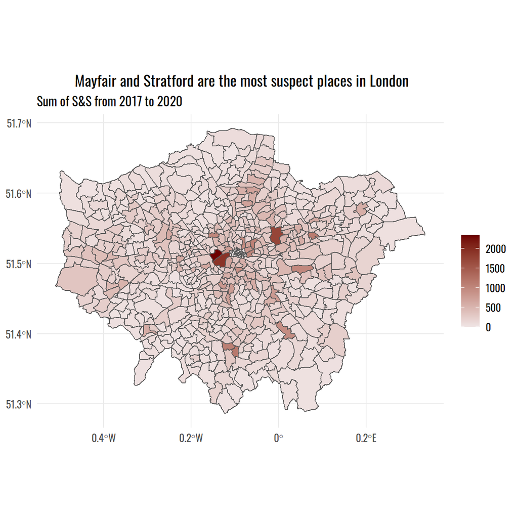

```r
# Count how many S&S happened inside each ward
london_wgs84 <- london_wgs84 %>%
  mutate(count = lengths(
    st_contains(london_wgs84,
                stop_search_offence_sf)))


p6 <- ggplot(data = london_wgs84, aes(fill = count)) +
   geom_sf() +
   scale_fill_gradient(low = "#f0e5e5", high = "#6e0000")+
  theme_minimal()+
  theme(text = element_text(size=12, family = "Oswald"),
        plot.title = element_text(hjust = 0.5))+
  labs(title = " Mayfair and Stratford are the most suspect places in London",
       subtitle = "Sum of S&S from 2017 to 2020", fill = "")

p6
```